# Replication of From Power to Inaction: Ambivalence Gives Pause to the Powerful by Durso, Brinol, & Petty (12x, Psychological Science)

## Link to original paper

http://journals.sagepub.com.stanford.idm.oclc.org/doi/pdf/10.1177/0956797616669947

## Link to repository

https://github.com/zainabhos/durso2016

## Link to paradigm

https://stanforduniversity.qualtrics.com/jfe/form/SV_cuSM6E8kngtp27P

## Methods

### Power Analysis

The effect size for this study was calculated using the GPower software. Because the original study used a MANOVA, the effect size was determined by using the original study’s data, accessed via the Open Science Framework (OSF.io). Using this data, the Pillai V. value for the interaction effect between ambivalence state (IV 1) and power state (IV 2) on the two measures of inaction (DV 1 and 2) was calculated as .0346, which allowed GPower to calculate an effect size based on the number of IVs and DVs. This effect size was determined to be .0358

The original study notes that they aimed for 120 participants in order to stay within conventions of including 20-40 participants per cell in a 2x2 factorial design. Due to the small effect size the authors found, i.e. .0358, we need 274 participants for 80%, 358 for 90%, and 496 for 95% power. However, due to logistical limitations, this study will aim to recruit the original number of participants who took the study, which is 126.

### Planned Sample

I will aim for 126 participants, and I will continue recruiting until that number is reached. Because authors seemed to be recruiting on an ongoing basis they stopped recruitment when they felt all 120 spots would be filled, but this recruitment will occur through a short period of time and will therefore continue until all 126 participants take the surveys. No preselction criteria or demographics indicated other than being an adult. However, in order to account for the difference sources in sampling, i.e. college campus in original study vs. Mturk in my study, I will incorporate a demographic variable to explore whether this poses a difference. Further, because this study was on Mturk, I restricted my sample to those who are in the US.

### Materials

Prompts will be followed exactly.

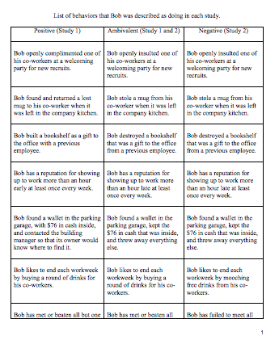

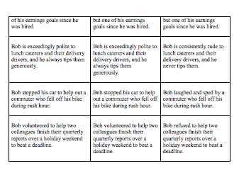

### Procedure

Exact procedure will be followed:

“As a cover story, participants were first informed that the study was being conducted with human-resourcesmanagement researchers at the (Stanford Graduate School of Business). Participants were told that the main goal was to understand how people make decisions about employees. At this point, participants received information that was ostensibly about an actual employee. This information differed according to whether they were in the ambivalent or in the univalent condition. After reading the employee’s profile, participants were assigned to the power induction, which involved the most commonly used procedure for priming differences in perceived power—writing about a previous episode in which they had high or low power (Galinsky et al., 2003). Participants were then asked to indicate the extent to which they would prefer to wait to make a decision about the employee (i.e., preference for inaction). Regardless of their preference, they were subsequently prompted to make a promote-or-not decision (Experiment 1) or a fire-or-not decision (Experiment 2) about the employee, and the time to make this decision was recorded.” It is noteworthy that in this study, verbal inaction, the extent to which they wish to wait before making a decision about Bob, is measured through our paradigm in an online setting. Further, behavioral inaction, the length of time participants take to actually make a decision, will be measured by assessing the amount of time they spend on the webpage in which they much make a decision about Bob.

Participants are also prompted to respond to three questions measuring their subjective ambivalence. This will be used as a manipulation check that was also used in the original study.

The only difference in this replication will be in that participants will only be given the positive attributes of Bob as a univalent case, i.e. experiment 1, insteading of reading both positive and negative attributes.

### Analysis Plan

Key analysis of interest will be a 2x2 between-subject factorial design - MANOVA

### Differences from Original Study

Two noteworthy differences exist:

1. Participants in original study were recruited on a college campus and participated in study in person. This is in contrast to this replication study which will use an online platform and recruit participants from a variety of educational backgrounds, i.e. not all will be college students. I will include a question on my demographics survey to inquire about educational level, but even then geographic region of college could impact results.
2. Original study aggregated experiment 1 and 2 results into one design, which means they did not differentiate between negative and positive univalent prompts. I will only be including positive univalent scripts, though I don’t think this will impact results because original study did not report significant differences between positive and negative scripts’ impact on decision making process. Further, I will not be including self-report power measures as they were only included in experiment 2.

### Methods Addendum (Post Data Collection)

Nothing to report in addition to analysis plan above.

## Results

### Data Preparation

#### Load Relevant Libraries and Functions

```r
library(tidyverse)
library(psych)
```

```r
library(dplyr)
library(heplots)
library(stringr)
```

#### Import data

```r
FinalData <- read.csv("/Users/Ikhlas/Desktop/Psych251/durso2016/Final Data.csv", stringsAsFactors=FALSE)

##### Removing first two rows from Qualtrics-imported data
FinalData = FinalData[3:nrow(FinalData), ]
```

#### Data exclusion / filtering

```r
#####Include only relevant columns
Final <- subset(FinalData, select = c(Finished, Q18, Manipulation.Check.2, Q23, Verbal.Inaction, Behavioral.Inaction_Page.Submit, Education, Ambivalentvs.Univalent_DO, Highvs.LowPower_DO, Behavioral.Inaction_Click.Count))

#####Include those who finished
Final<-Final[!(Final$Finished=="False"),]

####Include those who actually responded to the behavioral inaction measure
Final<-Final[!(Final$Behavioral.Inaction_Click.Count=="0"),]


#####Recode NAs
Final[Final==-99] <- NA

#####Rename Columns
names(Final)[names(Final) == 'Verbal.Inaction'] <- 'Verbal.Inaction'
names(Final)[names(Final) == 'Behavioral.Inaction_Page.Submit'] <- 'Behavioral.Inaction'
names(Final)[names(Final) == 'Behavioral.Inaction_Click.Count'] <- 'Behavioral.Inaction.Check'
names(Final)[names(Final) == 'Education'] <- 'Education'
names(Final)[names(Final) == 'Ambivalentvs.Univalent_DO'] <- 'Ambivalence.State'
names(Final)[names(Final) == 'Highvs.LowPower_DO'] <- 'Power.State'
names(Final)[names(Final) == 'Q18'] <- 'MC1'
names(Final)[names(Final) == 'Manipulation.Check.2'] <- 'MC2'
names(Final)[names(Final) == 'Q23'] <- 'MC3'


##### Variable cleaning - take the letters out of the DV values and change it to a numeric type
Final$Verbal.Inaction.Num = str_extract(Final$Verbal.Inaction, "[0-9]+")
Final$Verbal.Inaction.Num <- as.numeric(Final$Verbal.Inaction.Num)
Final$Behavioral.Inaction.Num <- as.numeric(Final$Behavioral.Inaction)


#####Create composite score for ambivalence manipulation check
Final$MC1 = str_extract(Final$MC1, "[0-9]+")
Final$MC2 = str_extract(Final$MC2, "[0-9]+")
Final$MC3 = str_extract(Final$MC3, "[0-9]+")
Final$MC1 <- as.integer(Final$MC1)
Final$MC2 <- as.integer(Final$MC2)
Final$MC3 <- as.integer(Final$MC3)
Final$Subjective.Ambivalence<-rowMeans(Final[, c('MC1','MC2','MC3')], na.rm = TRUE)

#####Assign Values to IV conditions and education levels

Final[Final$Ambivalence.State == "Ambivalence State 1",]$Ambivalence.State = 1
Final[Final$Ambivalence.State == "Ambivalence State 0",]$Ambivalence.State = 0
Final[Final$Power.State == "Power State 1",]$Power.State = 1
Final[Final$Power.State == "Power State 2",]$Power.State = 0

Final[Final$Education == "Less than high school degree",]$Education = 0
Final[Final$Education == "High school degree or equivalent (e.g., GED)",]$Education = 0
Final[Final$Education == "Some college but no degree",]$Education = 1
Final[Final$Education == "Associate degree",]$Education = 1
Final[Final$Education == "Bachelor degree",]$Education = 1
Final[Final$Education == "Graduate degree",]$Education = 1



#####Change IVs to factors instead of characters
Final$Ambivalence.State <- as.factor(Final$Ambivalence.State)
Final$Power.State <- as.factor(Final$Power.State)

#####Exclusion criteria - folks within 6 median absolute deviation

Final.Median.Stats = Final %>%
  summarize(Behavioral.Inaction.Num.M = median(Behavioral.Inaction.Num),
            Behavioral.Inaction.Num.MAD = median(abs(Behavioral.Inaction.Num-Behavioral.Inaction.Num.M)))

Final.Median.Stats
```

```
##   Behavioral.Inaction.Num.M Behavioral.Inaction.Num.MAD
## 1                    4.2275                       1.439
```

```r
Final_filtered = Final %>%
  filter(abs(Behavioral.Inaction.Num-Final.Median.Stats$Behavioral.Inaction.Num.M) < 6 * Final.Median.Stats$Behavioral.Inaction.Num.MAD)
```

#### Demographic Table - Education

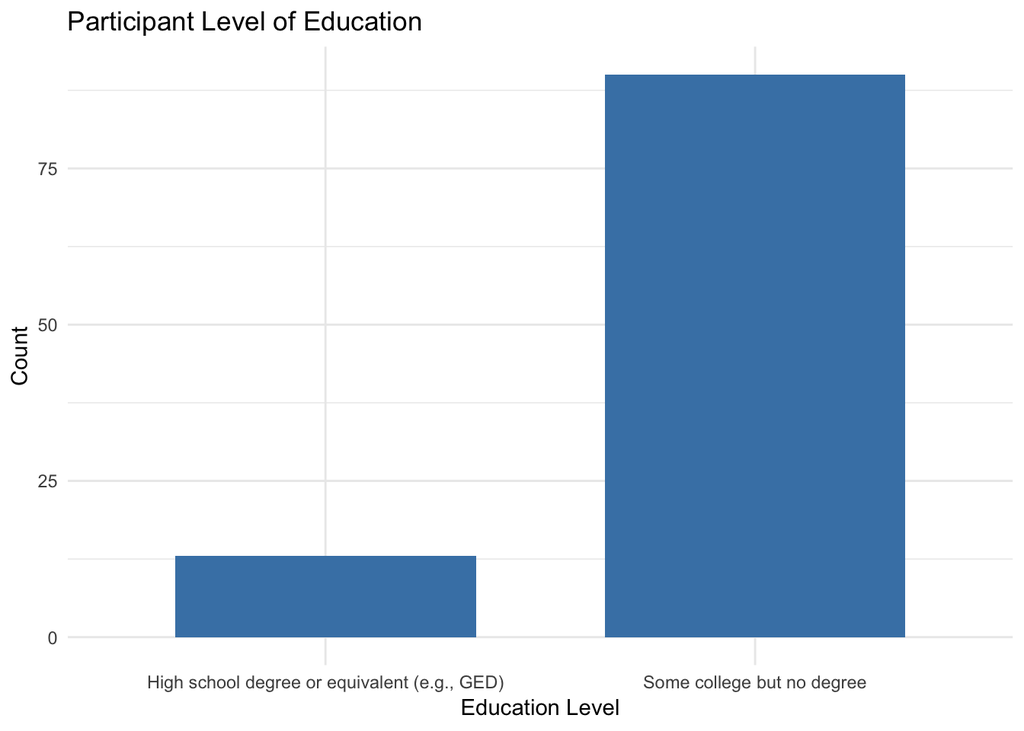

```r
ggplot(Final_filtered, aes(x=factor(Education)))+
  geom_bar(stat="count", width=0.7, fill="steelblue")+
  theme_minimal() +labs(x="Education Level" , y="Count" , title="Participant Level of Education")+
  scale_x_discrete(labels = c('High school degree or equivalent (e.g., GED)','Some college but no degree'))
```

### Confirmatory analysis

1. Manipulation checks - Two way factorial design to assess whether variables other than intended one is responsible for differences, i.e. did reading ambivalent vs. univalent profiles determine ambivalence level or did other variable such as power impact it as well? This is to ensure that participants reading ambivalent scenarios are in fact becoming more ambivalent and other conditions are not responsible. This step was included in the original study and will thus be completed as part of confirmatory analysis.

#### Manipulation Checks

```r
MC <- aov(Subjective.Ambivalence ~ Power.State*Ambivalence.State, data = Final_filtered)
summary(MC)
```

```
##                               Df Sum Sq Mean Sq F value   Pr(>F)
## Power.State                    1    0.3    0.30   0.043    0.837
## Ambivalence.State              1  245.1  245.14  35.054 4.64e-08 ***
## Power.State:Ambivalence.State  1    0.4    0.42   0.059    0.808
## Residuals                     99  692.3    6.99
## ---
## Signif. codes:  0 '***' 0.001 '**' 0.01 '*' 0.05 '.' 0.1 ' ' 1
```

#### Analysis of interest

2. Multivariate analysis of inaction - Two way factorial design to assess main effect of employee profile and significant interactions with power state

```r
#####MANOVA of Power state and ambivalence state as IVs and behavioral and verbal inaction as DVs

Result <- manova(cbind(Verbal.Inaction.Num, Behavioral.Inaction.Num) ~ Power.State*Ambivalence.State, data = Final_filtered)
summary(Result)
```

```
##                               Df   Pillai approx F num Df den Df Pr(>F)
## Power.State                    1 0.029814   1.5058      2     98 0.2269
## Ambivalence.State              1 0.086301   4.6282      2     98 0.0120 *
## Power.State:Ambivalence.State  1 0.005585   0.2752      2     98 0.7600
## Residuals                     99
## ---
## Signif. codes:  0 '***' 0.001 '**' 0.01 '*' 0.05 '.' 0.1 ' ' 1
```

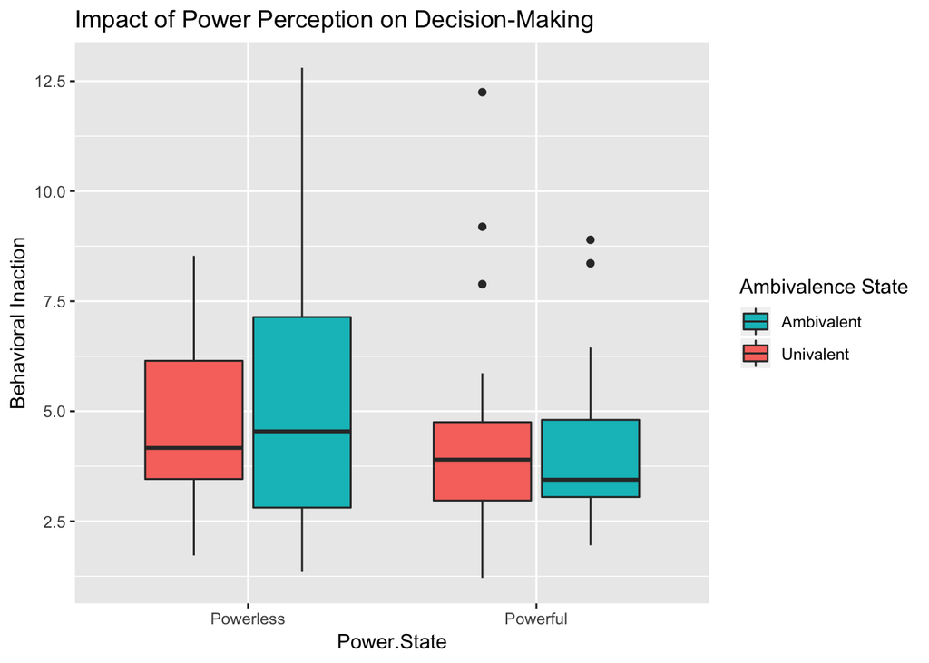

```r
#####Figures

p1 <- ggplot(Final_filtered, aes(x=Power.State, y=Behavioral.Inaction.Num), aes(fill = factor(Ambivalence.State))) +
       ggtitle("Impact of Power Perception on Decision-Making") + geom_boxplot(aes(fill = factor(Ambivalence.State))) +
        guides(fill=guide_legend(title="Ambivalence State")) + ylab("Behavioral Inaction")

p1 + scale_fill_discrete(name="Ambivalence State",
                         breaks=c("1", "0"),
                         labels=c("Ambivalent", "Univalent")) +
                         scale_x_discrete(labels = c('Powerless','Powerful'))
```

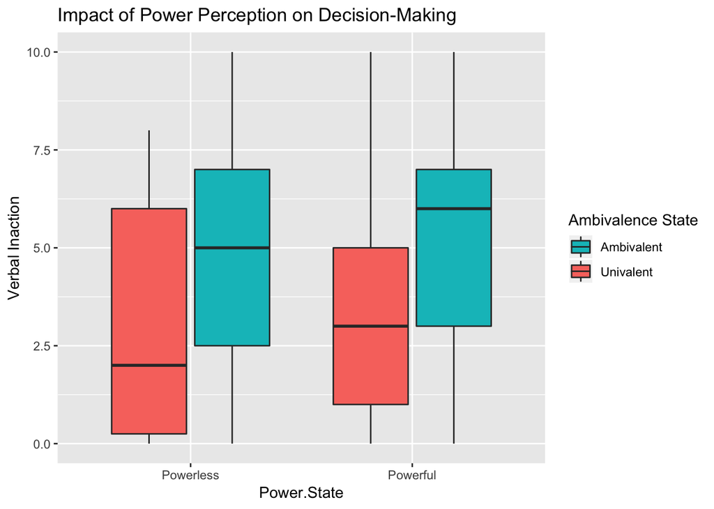

```r
p2 <- ggplot(Final_filtered, aes(x=Power.State, y=Verbal.Inaction.Num), aes(fill = factor(Ambivalence.State))) +
       ggtitle("Impact of Power Perception on Decision-Making") + geom_boxplot(aes(fill = factor(Ambivalence.State))) +
        guides(fill=guide_legend(title="Ambivalence State")) + ylab("Verbal Inaction")

p2 + scale_fill_discrete(name="Ambivalence State",
                         breaks=c("1", "0"),
                         labels=c("Ambivalent", "Univalent")) +
                         scale_x_discrete(labels = c('Powerless','Powerful'))
```

### Original findings

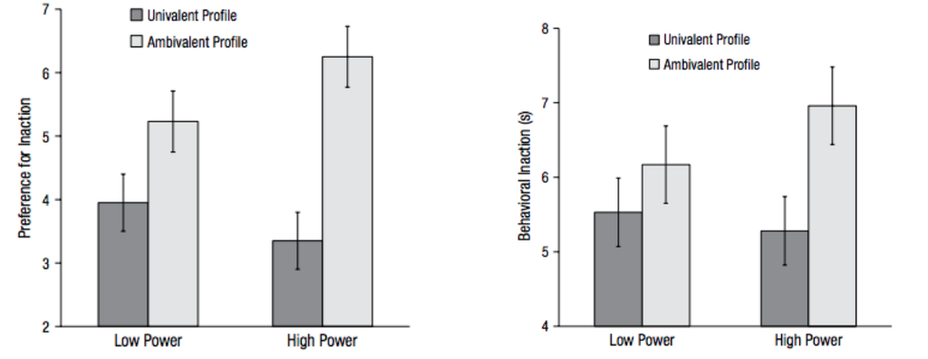

Material1

### Exploratory analyses

#### Check whether behavioral inaction or verbal inaction impact DVs separately

```r
Result2 <- aov(Verbal.Inaction.Num ~ Power.State*Ambivalence.State, data = Final_filtered)
summary(Result2)
```

```
##                               Df Sum Sq Mean Sq F value  Pr(>F)
## Power.State                    1    1.0    1.02   0.111 0.73987
## Ambivalence.State              1   83.0   83.00   9.016 0.00339 **
## Power.State:Ambivalence.State  1    0.0    0.03   0.003 0.95424
## Residuals                     99  911.4    9.21
## ---
## Signif. codes:  0 '***' 0.001 '**' 0.01 '*' 0.05 '.' 0.1 ' ' 1
```

```r
Result3 <- aov(Behavioral.Inaction.Num ~ Power.State*Ambivalence.State, data = Final_filtered)
summary(Result3)
```

```
##                               Df Sum Sq Mean Sq F value Pr(>F)
## Power.State                    1   17.8  17.835   2.943 0.0894 .
## Ambivalence.State              1    1.8   1.808   0.298 0.5861
## Power.State:Ambivalence.State  1    3.3   3.343   0.552 0.4594
## Residuals                     99  599.9   6.060
## ---
## Signif. codes:  0 '***' 0.001 '**' 0.01 '*' 0.05 '.' 0.1 ' ' 1
```

#### Check whether education is a moderator or impacts results

```r
Result1 <- manova(cbind(Verbal.Inaction.Num, Behavioral.Inaction.Num) ~ Power.State*Ambivalence.State*Education, data = Final_filtered)
summary(Result1)
```

```
##                                         Df   Pillai approx F num Df den Df
## Power.State                              1 0.030185   1.4628      2     94
## Ambivalence.State                        1 0.087897   4.5293      2     94
## Education                                1 0.000103   0.0048      2     94
## Power.State:Ambivalence.State            1 0.005720   0.2704      2     94
## Power.State:Education                    1 0.002047   0.0964      2     94
## Ambivalence.State:Education              1 0.009356   0.4439      2     94
## Power.State:Ambivalence.State:Education  1 0.020917   1.0041      2     94
## Residuals                               95
##                                          Pr(>F)
## Power.State                             0.23680
## Ambivalence.State                       0.01325 *
## Education                               0.99518
## Power.State:Ambivalence.State           0.76368
## Power.State:Education                   0.90818
## Ambivalence.State:Education             0.64286
## Power.State:Ambivalence.State:Education 0.37027
## Residuals
## ---
## Signif. codes:  0 '***' 0.001 '**' 0.01 '*' 0.05 '.' 0.1 ' ' 1
```

## Discussion

### Summary of Replication Attempt

This demonstrates that our results did not replicate because our main analysis of interest was in the interaction between ambivalence and power state. The effect of the ambivalent state was expected and therefore its significance does not point to a replication. Further, our boxplots suggest that the behavioral inaction DVs did not even demonstrate a difference between the ambivalent state and respondants on all categories had similar response times. While in the verbal inaction boxplot we can see a notable difference between the ambivalent vs. univalent conditions, again there does not seem to be a difference based on the powerful vs. powerless state.

### Commentary

To further explore our results, we conducted an ANOVA on each DV. As expected from initial boxplots, only the verbal inaction DV demonstrated a significant main effect of ambivalence state. That is, participants in the ambivalent state reported higher ambivalence on the verbal inaction measure. The behavioral inaction DV did not demonstrate any significant effect. That is, there was no difference between the length of time participants took to make a decision about Bob, regardless of their ambivalence or power state. This may point to the fact that length of time spent on a webpage inquiring about participant decisions was not a robust measure of the extent of their inaction. Many confounders could impact how long respondants spend on this page, which can be impacting the results. This is a potntial limitation of our replication paradigm. A second noteworthy limitation is in the use of writing about a powerful moment as a way of evoking a sense of power. Evoking a robust sense of powerfulness is already difficult in in-lab settings where participants may spend more time thinking about this topic, let alone on an online platform. This may speak to the non-replicability of our results. While we do not have a subjective measure of their power state, participants most likely did not experience a shift in how powerful or powerless they felt prior to responding to our DVs. This may speak to limitations in attempting to evoke a state of mind through a short online survey. Finally, we explored one potential moderator of our findings by inquiring about education levels. Since the original study only included undergraduate students and our study was open to all adults, we included education level as a potential covariate.